# atividade_4

```r
library(dplyr)
library(car)
library(rstatix)
library(emmeans)
library(ggplot2)
library(knitr)
library(kableExtra)
library(htmltools)
```

## 0.1 Instruções

Siga as instruções abaixo. Documente *todos* os seus passos em um script. Comente no seu script *todos* os seus passos e explique a si mesma(o) suas escolhas e estratégias. Se você se beneficiou da assistência de outra pessoa, sempre reconheça isso em comentários no código.

## 0.2 Roteiro

**Análise Espacial**

1. Instale e abre [o pacote `geobr` do IBGE](https://github.com/ipeaGIT/geobr). Leia as instruções no site de github do pacote e use a função `read_municipality()` para acessar todos os municípios do estado de São Paulo em 2018.

```r
# install.packages("geobr")
library("tidyverse")
library("sf")
library("geobr")
library("rmarkdown")
library("knitr")
muns_SP <- read_municipality(code_muni="SP", year=2018)

muns_SP
```

2. Use a funcionalidade da família de `map` para aplicar a função `read_municipality` para os cinco estados seguintes em uma linha única de código: SP, RJ, MT, RS e RN (todos para o ano de 2018).

```r
estados <- c("SP", "RJ", "MT", "RS", "RN")
muns_estados <- estados %>% map(read_municipality, year=2018)

muns_estados
```

3. Baixe, unzip e abre em R o arquivo da população paulista em 2010 [do site do IBGE](https://www.ibge.gov.br/estatisticas/downloads-estatisticas.html), ‘Censos’ -> ‘Censo_Demografico_2010’ -> ‘resultados’ -> ‘total_populacao_sao_paulo.zip’.

```r
library("readxl")
popn_sp  <- read_excel("total_populacao_sao_paulo.xls")

# obs: se não limpar as planilhas, as duas últimas linhas contém dados "errados": o total do estado e o link do site do IBGE de onde a planilha foi tirada

popn_sp
```

| Código do município | Nome do município | Total da população 2000 | Total de homens | Total de mulheres | Total da população urbana | Total da população rural | Total da população 2010 |
| --- | --- | --- | --- | --- | --- | --- | --- |
| 3500105 | Adamantina | 33497 | 16375 | 17422 | 31948 | 1849 | 33797 |
| 3500204 | Adolfo | 3684 | 1787 | 1770 | 3200 | 357 | 3557 |
| 3500303 | Aguaí | 28195 | 16224 | 15944 | 29021 | 3147 | 32168 |
| 3500402 | Águas da Prata | 7131 | 3742 | 3838 | 6766 | 814 | 7580 |
| 3500501 | Águas de Lindóia | 16190 | 8453 | 8808 | 17108 | 153 | 17261 |
| 3500550 | Águas de Santa Bárbara | 5224 | 2777 | 2821 | 4256 | 1342 | 5598 |
| 3500600 | Águas de São Pedro | 1883 | 1257 | 1446 | 2703 | 0 | 2703 |
| 3500709 | Agudos | 32484 | 17086 | 17446 | 32999 | 1533 | 34532 |
| 3500758 | Alambari | 3650 | 2457 | 2429 | 3672 | 1214 | 4886 |
| 3500808 | Alfredo Marcondes | 3697 | 1980 | 1911 | 3255 | 636 | 3891 |

[output cut: 635 more lines]

4. Queremos mapear dados da população por município. Identifique o chave apropriado, e cruze o banco de população com o banco das fronteiras dos municípios de SP.

```r
popn_sp <- popn_sp %>% mutate(code_muni=as.numeric(`Código do município`))
muns_SP <- muns_SP %>% left_join(popn_sp, by="code_muni")
popn_sp
```

| Código do município | Nome do município | Total da população 2000 | Total de homens | Total de mulheres | Total da população urbana | Total da população rural | Total da população 2010 | code_muni |
| --- | --- | --- | --- | --- | --- | --- | --- | --- |
| 3500105 | Adamantina | 33497 | 16375 | 17422 | 31948 | 1849 | 33797 | 3500105 |
| 3500204 | Adolfo | 3684 | 1787 | 1770 | 3200 | 357 | 3557 | 3500204 |
| 3500303 | Aguaí | 28195 | 16224 | 15944 | 29021 | 3147 | 32168 | 3500303 |
| 3500402 | Águas da Prata | 7131 | 3742 | 3838 | 6766 | 814 | 7580 | 3500402 |
| 3500501 | Águas de Lindóia | 16190 | 8453 | 8808 | 17108 | 153 | 17261 | 3500501 |
| 3500550 | Águas de Santa Bárbara | 5224 | 2777 | 2821 | 4256 | 1342 | 5598 | 3500550 |
| 3500600 | Águas de São Pedro | 1883 | 1257 | 1446 | 2703 | 0 | 2703 | 3500600 |
| 3500709 | Agudos | 32484 | 17086 | 17446 | 32999 | 1533 | 34532 | 3500709 |
| 3500758 | Alambari | 3650 | 2457 | 2429 | 3672 | 1214 | 4886 | 3500758 |
| 3500808 | Alfredo Marcondes | 3697 | 1980 | 1911 | 3255 | 636 | 3891 | 3500808 |

[output cut: 635 more lines]

```r
muns_SP
```

| code_muni | name_muni | code_state | abbrev_state | Código do município | Nome do município | Total da população 2000 | Total de homens | Total de mulheres | Total da população urbana | Total da população rural | Total da população 2010 | geom |
| --- | --- | --- | --- | --- | --- | --- | --- | --- | --- | --- | --- | --- |
| 3500105 | Adamantina | 35 | SP | 3500105 | Adamantina | 33497 | 16375 | 17422 | 31948 | 1849 | 33797 |  |
| 3500204 | Adolfo | 35 | SP | 3500204 | Adolfo | 3684 | 1787 | 1770 | 3200 | 357 | 3557 |  |
| 3500303 | Aguaí | 35 | SP | 3500303 | Aguaí | 28195 | 16224 | 15944 | 29021 | 3147 | 32168 |  |
| 3500402 | Águas Da Prata | 35 | SP | 3500402 | Águas da Prata | 7131 | 3742 | 3838 | 6766 | 814 | 7580 |  |
| 3500501 | Águas De Lindóia | 35 | SP | 3500501 | Águas de Lindóia | 16190 | 8453 | 8808 | 17108 | 153 | 17261 |  |
| 3500550 | Águas De Santa Bárbara | 35 | SP | 3500550 | Águas de Santa Bárbara | 5224 | 2777 | 2821 | 4256 | 1342 | 5598 |  |
| 3500600 | Águas De São Pedro | 35 | SP | 3500600 | Águas de São Pedro | 1883 | 1257 | 1446 | 2703 | 0 | 2703 |  |
| 3500709 | Agudos | 35 | SP | 3500709 | Agudos | 32484 | 17086 | 17446 | 32999 | 1533 | 34532 |  |
| 3500758 | Alambari | 35 | SP | 3500758 | Alambari | 3650 | 2457 | 2429 | 3672 | 1214 | 4886 |  |
| 3500808 | Alfredo Marcondes | 35 | SP | 3500808 | Alfredo Marcondes | 3697 | 1980 | 1911 | 3255 | 636 | 3891 |  |

[output cut: 635 more lines]

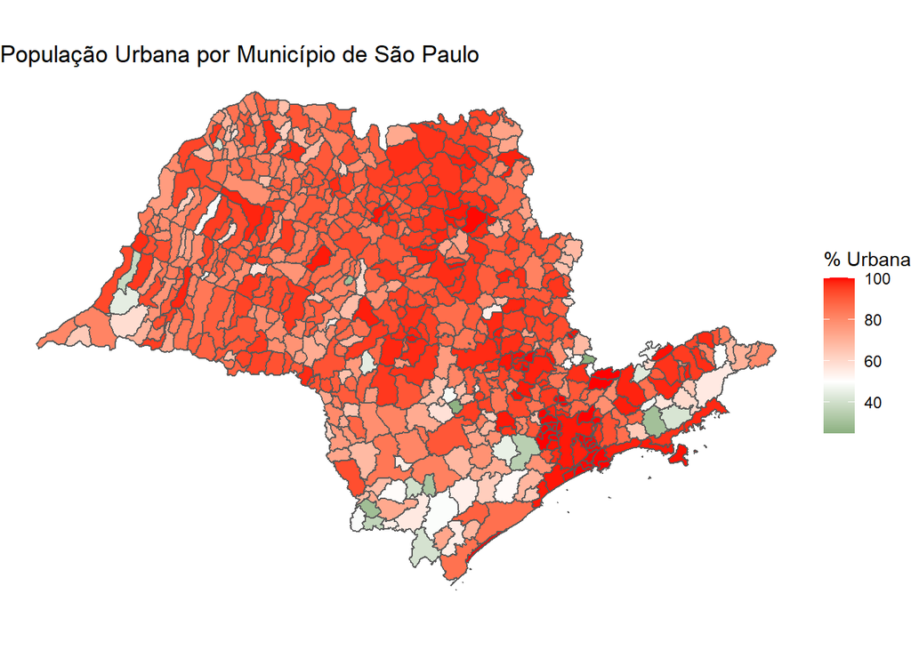

```r
muns_SP <- muns_SP %>% mutate(taxa_urbana=100*(`Total da população urbana`/`Total da população 2010`))
muns_SP %>%
  ggplot() +
  geom_sf(aes(fill=taxa_urbana)) +
  scale_fill_gradient2(name="% Urbana", low="dark green", mid="white", high="red", midpoint=50) +
  theme_void() +
  ggtitle("População Urbana por Município de São Paulo")
```

```r
muns_SP
```

|  | code_muni | name_muni | code_state | abbrev_state | Código do município | Nome do município | Total da população 2000 | Total de homens | Total de mulheres | Total da população urbana | Total da população rural | Total da população 2010 | geom | taxa_urbana |
| --- | --- | --- | --- | --- | --- | --- | --- | --- | --- | --- | --- | --- | --- | --- |
| 1 | 3500105 | Adamantina | 35 | SP | 3500105 | Adamantina | 33497 | 16375 | 17422 | 31948 | 1849 | 33797 |  | 94.52910 |
| 2 | 3500204 | Adolfo | 35 | SP | 3500204 | Adolfo | 3684 | 1787 | 1770 | 3200 | 357 | 3557 |  | 89.96345 |
| 3 | 3500303 | Aguaí | 35 | SP | 3500303 | Aguaí | 28195 | 16224 | 15944 | 29021 | 3147 | 32168 |  | 90.21699 |
| 4 | 3500402 | Águas Da Prata | 35 | SP | 3500402 | Águas da Prata | 7131 | 3742 | 3838 | 6766 | 814 | 7580 |  | 89.26121 |
| 5 | 3500501 | Águas De Lindóia | 35 | SP | 3500501 | Águas de Lindóia | 16190 | 8453 | 8808 | 17108 | 153 | 17261 |  | 99.11361 |
| 6 | 3500550 | Águas De Santa Bárbara | 35 | SP | 3500550 | Águas de Santa Bárbara | 5224 | 2777 | 2821 | 4256 | 1342 | 5598 |  | 76.02715 |
| 7 | 3500600 | Águas De São Pedro | 35 | SP | 3500600 | Águas de São Pedro | 1883 | 1257 | 1446 | 2703 | 0 | 2703 |  | 100.00000 |
| 8 | 3500709 | Agudos | 35 | SP | 3500709 | Agudos | 32484 | 17086 | 17446 | 32999 | 1533 | 34532 |  | 95.56064 |
| 9 | 3500758 | Alambari | 35 | SP | 3500758 | Alambari | 3650 | 2457 | 2429 | 3672 | 1214 | 4886 |  | 75.15350 |
| 10 | 3500808 | Alfredo Marcondes | 35 | SP | 3500808 | Alfredo Marcondes | 3697 | 1980 | 1911 | 3255 | 636 | 3891 |  | 83.65459 |

[output cut: 635 more lines]

**Testes Estatístos e Regressões**

6. Faça um teste de shapiro para avaliar se a taxa urbana municipal é distribuida de forma normal.

```r
muns_SP %>% pull(taxa_urbana) %>% shapiro.test()
```

```
##
##  Shapiro-Wilk normality test
##
## data:  .
## W = 0.86591, p-value < 2.2e-16
```

7. Execute uma regressão para avaliar se a taxa urbana (a variável dependente) é associada com a população total do município (a variável independente). Apresente o resultado numa tabela bem-formatada.

```r
library("stargazer")
muns_SP %>% lm(taxa_urbana ~  + `Total da população 2010`, data=.)  %>%
  stargazer(type="html", title="Preditores da Taxa Urbana por Município")
```

**Preditores da Taxa Urbana por Município**

|  | *Dependent variable:* |
| --- | --- |
|  | taxa_urbana |
| `Total da população 2010` | 0.00000*** |
|  | (0.00000) |
| Constant | 84.034*** |
|  | (0.565) |
| Observations | 645 |
| R<sup>2</sup> | 0.013 |
| Adjusted R<sup>2</sup> | 0.012 |
| Residual Std. Error | 14.214 (df = 643) |
| F Statistic | 8.558*** (df = 1; 643) |
| *Note:* | p<0.1; p<0.05; p<0.01 |

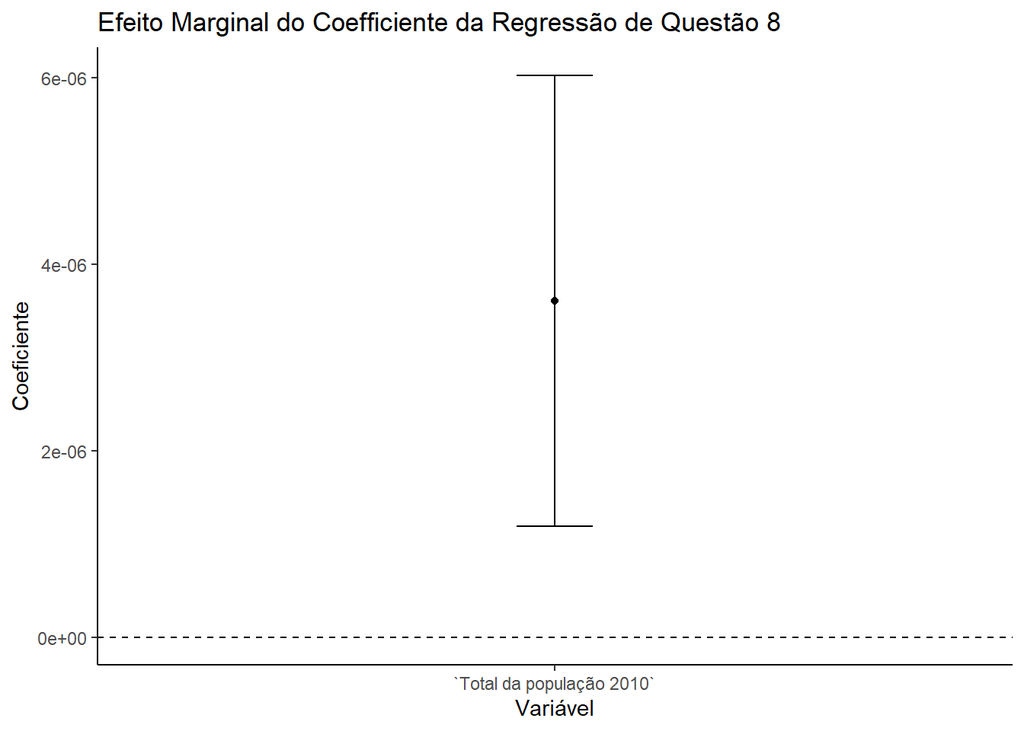

```r
library("broom")
muns_SP %>% lm(taxa_urbana ~  + `Total da população 2010`, data=.) %>%
  tidy() %>%
  mutate(conf.lo=estimate-1.96*std.error,
         conf.hi=estimate+1.96*std.error) %>%
  filter(term!="(Intercept)") %>%
  ggplot() +
  geom_point(aes(x=term, y=estimate)) +
  geom_errorbar(aes(x=term, y=estimate, ymin=conf.lo, ymax=conf.hi), width=0.1) +
  geom_hline(yintercept=0, lty=2) +
  theme_classic() +
  ggtitle("Efeito Marginal do Coefficiente da Regressão de Questão 8") +
  xlab("Variável") +
  ylab("Coeficiente")
```

**Análise de Texto**

9. Use [o link aqui](https://escriba.camara.leg.br/escriba-servicosweb/pdf/59638) para acessar em R um PDF da discussão na Camara dos Deputados no dia 21 de Maio de 2020. Transforme o PDF em texto simples.

```r
library("pdftools")
text <- tibble(páginas=pdf_text("https://escriba.camara.leg.br/escriba-servicosweb/pdf/59638"))

text
```

| páginas |
| --- |
| Sessão de: 21/05/2020 Notas Taquigráficas CONGRESSO NACIONAL\n\n\n\n\n CONGRESSO NACIONAL\n 10ª SESSÃO\n (SESSÃO DO CONGRESSO NACIONAL - CÂMARA DOS DEPUTADOS (VIRTUAL))\n Em 21 de Maio de 2020\n (Quin… |
| Sessão de: 21/05/2020 Notas Taquigráficas CONGRESSO NACIONAL\n\n\nAntes, porém, faço um registro de agradecimento ao conjunto de Deputados e Senadores, à Liderança do Governo, à\nSEGOV, aos Ministros,… |
| Sessão de: 21/05/2020 Notas Taquigráficas CONGRESSO NACIONAL\n\n\nSuplementar R$ 2,9 milhões na ação de '00NQ - Contribuição à Associação para Promoção da Excelência do Software\nBrasileiro — SOFTEX' … |
| Sessão de: 21/05/2020 Notas Taquigráficas CONGRESSO NACIONAL\n\nde 11 de novembro de 2019 (Lei de Diretrizes Orçamentárias para 2020); e na Lei nº 13.971, de 27 de dezembro de 2019\n(Plano Plurianual … |
| Sessão de: 21/05/2020 Notas Taquigráficas CONGRESSO NACIONAL\n\n\nO SR. PRESIDENTE (Marcos Pereira. REPUBLICANOS - SP) - Pois não, Deputado Enio Verri.\nO SR. ENIO VERRI (PT - PR) - Bom dia, Sr. Presi… |
| Sessão de: 21/05/2020 Notas Taquigráficas CONGRESSO NACIONAL\n\n\nSr. Presidente, colegas Deputados, Deputadas e toda a população que nos assiste neste momento, está acontecendo um fato\nhistórico nes… |
| Sessão de: 21/05/2020 Notas Taquigráficas CONGRESSO NACIONAL\n\n\nBolsonaro abriu mão de ser um Governo constitucional. O Governo Bolsonaro ataca de tal forma e comete tais crimes\nde responsabilidade… |
| Sessão de: 21/05/2020 Notas Taquigráficas CONGRESSO NACIONAL\n\n\nEm segundo lugar, na economia, eles não querem socorrer os pobres, pelo contrário. O Guedes continua querendo dar 200\nreais para 80 m… |
| Sessão de: 21/05/2020 Notas Taquigráficas CONGRESSO NACIONAL\n\n8 bilhões de reais; para Cuba, 2 bilhões 557 milhões de reais. Qual foi o retorno? Onde está o dinheiro? Nós nunca mais\nvamos ver a sua… |
| Sessão de: 21/05/2020 Notas Taquigráficas CONGRESSO NACIONAL\n\n\nNós estamos cobrando que haja hospital de campanha no interior do Estado, principalmente na região de Tabatinga, de\nSão Gabriel e no … |

[output cut: 22 more lines]

10. Precisamos processar e preparar o texto para a análise. Segue os seguintes passos:
    1. Insera o texto num tibble
    2. No PDF é possível ver que as falas dos deputados distintos sempre começam com ‘O SR.’ ou ‘A SRA.’ então vamos usar estes strings para dividir o texto por Deputado. Use `str_split` para dividir o texto baseado nos strings ‘O SR.’ ou ‘A SRA.’ e salve os resultados numa nova coluna.
    3. Em seguida, `unnest()` os dados para que cada fala de cada deputado é uma linha separada no tibble.
    4. Use `separate` para dividir a fala de cada deputado em duas colunas: O nome do Deputado, e o Discurso, usando o seguinte string como divisor: `"\\) - "`
    5. O resultado deve conter umas linhas em que a coluna ‘Deputado’ não é uma pessoa, mas começa com “Sessão”. Use `filter` para tirar essas linhas que começam com “Sessão” na coluna de ‘Deputado’.
    6. Ainda, o nome do deputado fica desarrumado por causa de conteúdo em parenteses. Para identificar os deputados únicos, use `separate` para dividir a coluna do nome de Deputado em o nome e o conteúdo nos parenteses (que não importa para nos), usando o seguinte string como divisor: `" \\("`.
    7. Tire as colunas desnecessárias para que temos apenas as duas colunas: Nome do Deputado, e Discurso.

```r
text2 <- text %>% mutate(split=str_split(páginas, "O SR.|A SRA.")) %>%
  select(-páginas) %>%
  unnest() %>%
  separate(split, "\\) - ", into=c("Deputado", "Discurso")) %>%
  filter(!(str_detect(Deputado, "^Sessão"))) %>%
  separate(Deputado, " \\(", into=c("Deputado", "Ignorar")) %>%
  select(-Ignorar)

text2
```

| Deputado | Discurso |
| --- | --- |
| PRESIDENTE | O sistema acusa a participação de 363 Senhoras\nDeputadas e Senhores Deputados nesta sessão.\nHavendo número regimental, declaro aberta a sessão.\nNos termos do art. 7º do Ato da Comissão Diretora do … |
| PRESIDENTE | Declaro aberta a Ordem do Dia.\nConsta na pauta o Projeto de Lei do Congresso Nacional nº 8, de 2020.\nPassa-se à deliberação da matéria.\nProjeto de Lei (CN) nº 8, de 2020, da Presidência da Repúblic… |
| MARCOS ROGÉRIO | Sr. Presidente, Sras. e Srs.\nDeputados, Sras. e Srs. Senadores, considerando o necessário distanciamento social, farei a retirada da máscara para poder\nfazer a leitura do meu relatório.\nSr. Preside… |
| PRESIDENTE | Obrigado, Senador Marcos Rogério.\nO parecer concluiu pela aprovação do projeto na forma do substitutivo. Ao projeto foram apresentados requerimentos de\ndestaques, nos termos do art. 132-A da Resoluç… |
| ENIO VERRI | Sr. Presidente...\n\n 4/32\n |
| PRESIDENTE | Pois não, Deputado Enio Verri.\n |
| ENIO VERRI | Bom dia, Sr. Presidente!\nEu apenas queria pedir a fala como Líder, após a intervenção do Deputado João Daniel, por favor.\n\n |
| PRESIDENTE | Depois do Deputado João Daniel, então V.Exa. terá\na palavra.\nDeputado João Daniel, V.Exa. tem 5 minutos.\n |
| JOÃO DANIEL | Muito obrigado, Sr. Presidente. Obrigado a\ntodos. Meus cumprimentos a todos os Parlamentares do Congresso Nacional nesta sessão de hoje.\nO nosso partido e a nossa bancada têm sido firmes e fortes e … |
| PRESIDENTE | Obrigado, Deputado João Daniel.\nTem a palavra a Deputada Maria do Rosário. (Pausa.)\n |

[output cut: 118 more lines]

```r
library("tidytext")
library("textstem")
library("lexiconPT")
stopwords <- get_stopwords(language="pt") %>%
  rename(palavra=word)
text3 <- text2 %>% unnest_tokens(palavra, Discurso, strip_numeric=TRUE) %>%
  anti_join(stopwords, by="palavra") %>%
  mutate(stem=stem_words(palavra, language="pt"))

stopwords
```

| palavra | lexicon |
| --- | --- |
| de | snowball |
| a | snowball |
| o | snowball |
| que | snowball |
| e | snowball |
| do | snowball |
| da | snowball |
| em | snowball |
| um | snowball |
| para | snowball |

[output cut: 193 more lines]

```r
text3
```

| Deputado | palavra | stem |
| --- | --- | --- |
| PRESIDENTE | sistema | sistem |
| PRESIDENTE | acusa | acus |
| PRESIDENTE | participação | particip |
| PRESIDENTE | senhoras | senhor |
| PRESIDENTE | deputadas | deput |
| PRESIDENTE | senhores | senhor |
| PRESIDENTE | deputados | deput |
| PRESIDENTE | nesta | nest |
| PRESIDENTE | sessão | sessã |
| PRESIDENTE | havendo | hav |

[output cut: 7025 more lines]

```r
text2 %>% paged_table()
```

| Deputado | Discurso |
| --- | --- |
| PRESIDENTE | O sistema acusa a participação de 363 Senhoras\nDeputadas e Senhores Deputados nesta sessão.\nHavendo número regimental, declaro aberta a sessão.\nNos termos do art. 7º do Ato da Comissão Diretora do … |
| PRESIDENTE | Declaro aberta a Ordem do Dia.\nConsta na pauta o Projeto de Lei do Congresso Nacional nº 8, de 2020.\nPassa-se à deliberação da matéria.\nProjeto de Lei (CN) nº 8, de 2020, da Presidência da Repúblic… |
| MARCOS ROGÉRIO | Sr. Presidente, Sras. e Srs.\nDeputados, Sras. e Srs. Senadores, considerando o necessário distanciamento social, farei a retirada da máscara para poder\nfazer a leitura do meu relatório.\nSr. Preside… |
| PRESIDENTE | Obrigado, Senador Marcos Rogério.\nO parecer concluiu pela aprovação do projeto na forma do substitutivo. Ao projeto foram apresentados requerimentos de\ndestaques, nos termos do art. 132-A da Resoluç… |
| ENIO VERRI | Sr. Presidente...\n\n 4/32\n |
| PRESIDENTE | Pois não, Deputado Enio Verri.\n |
| ENIO VERRI | Bom dia, Sr. Presidente!\nEu apenas queria pedir a fala como Líder, após a intervenção do Deputado João Daniel, por favor.\n\n |
| PRESIDENTE | Depois do Deputado João Daniel, então V.Exa. terá\na palavra.\nDeputado João Daniel, V.Exa. tem 5 minutos.\n |
| JOÃO DANIEL | Muito obrigado, Sr. Presidente. Obrigado a\ntodos. Meus cumprimentos a todos os Parlamentares do Congresso Nacional nesta sessão de hoje.\nO nosso partido e a nossa bancada têm sido firmes e fortes e … |
| PRESIDENTE | Obrigado, Deputado João Daniel.\nTem a palavra a Deputada Maria do Rosário. (Pausa.)\n |

[output cut: 118 more lines]

```r
data("oplexicon_v3.0") #Abrir o banco de dados de sentimentos
sentimento <- oplexicon_v3.0 %>% select(term, polarity) %>%
  rename(palavra=term)
text3 <- text3 %>% left_join(sentimento, by="palavra")
text3 %>% group_by(Deputado) %>%
  summarize(sentimento=sum(polarity, na.rm=T)) %>%
  arrange(-sentimento) %>%
  slice(1, n()) %>%
  kable()
```

| Deputado | sentimento |
| --- | --- |
| AFONSO MOTTA | 16 |
| PRESIDENTE | -34 |

```r
sentimento
```

| palavra | polarity |
| --- | --- |
| =[ | -1 |
| =@ | -1 |
| =p | -1 |
| =P | -1 |
| =x | -1 |
| =d | 1 |
| =D | 1 |
| ;) | 1 |
| ;) | 1 |
| ;@ | -1 |

[output cut: 9990 more lines]